# Using the STASNet package

Mathurin Dorel, Bertram Klinger

2020-04-03

# `STASNet`

## Package flowchart

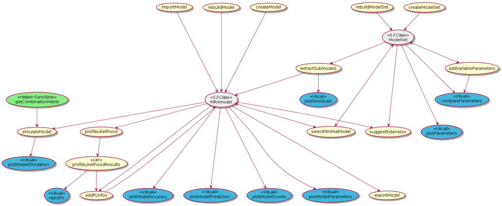

**Loading the library:**

```r
library(STASNet)
```

STASNet (STeady-STate Analysis of Signalling Networks) is a package that uses a modified version of Modular Response Analysis (as described in Klinger at al. 2013 and Dorel et al.2018) to quantify, locally adjust and analyse signalling networks from perturbation data. In here we will give an example for the kind of inputs required by the modelling pipeline along with a few further analysis examples. In general our methodology can be applied to two scenarios: (i) the basic MRAmodel approach to model single data sets (i.e. one cell line data) and (ii) using the Modelset extension to jointly model several data sets (e.g. a cell line panel).

**NOTE** Various scripts are available in the “inst/” folder of `STASNet` to run the fitting procedure from the command line (you may have to change the path to ‘Rscript’ in the first line)

## MRAmodel

### Example dataset

As minimal input the model requires three inputs:

- network (a prior network as named adjacency matrix or a two column table FROM TO)
- basal (a vector with names of nodes that are active in absence of external stimuli)
- midas_data (perturbation data in MIDAS format ([Saez-Rodriguez et al. 2008](https://doi.org/10.1093/bioinformatics/btn018)))  
  (- [midas_var] (optionally one can provide coefficient of variation data in same format and size as midas_data))

```r
network = rbind(c("N1", "N2"), c("N2", "N3"), c("N2", "N5"), c("N5", "N4"), c("N3", "N4")) # Two column table:  FROM -> TO
basal = c("N2", "N3", "N4", "N5") # Column vector of nodes active in ground state
midas_data = as.data.frame(matrix(0, nrow=4, ncol=7,
    dimnames=list(NULL, c("ID:type", "TR:N1", "TR:N2i", "DA:ALL", "DV:N2", "DV:N3", "DV:N4"))))
midas_data[,1] = c("c", "t", "t", "t") # Type of experiment
midas_data[,c(2,3)] = cbind(c(0,1,1,0), c(0,0,1,1)) # Perturbations
midas_data[,c(5:7)] = cbind(c(111, 263, 225, 97), c(103, 50, 128, 168), c(56, 618, 147, 20)) # Measurements
print(midas_data)
```

```
##   ID:type TR:N1 TR:N2i DA:ALL DV:N2 DV:N3 DV:N4
## 1       c     0      0      0   111   103    56
## 2       t     1      0      0   263    50   618
## 3       t     1      1      0   225   128   147
## 4       t     0      1      0    97   168    20
```

### Modelling

By using the input files one can create the MRA-based model.

```r
model = createModel(model_links = network,
                    basal_file = basal,
                    data.stimulation = midas_data,
                    inits = 100,
                    model_name = "example")
```

```
## Initializing the model parameters... (100 random samplings) with 1 cores
```

```
## Looking for identifiable correlations...
```

```
## Generating initial samples
```

```
## Assigning precorrelated parameters
```

```
## Sampling terminated.
```

```
## Fitting completed.
```

```
## 0 NA and  0 infinite residuals
```

```
## Ensuring convergence
## Ensuring convergence
## Ensuring convergence
## Ensuring convergence
## Ensuring convergence
## Ensuring convergence
## Ensuring convergence
## Ensuring convergence
## Ensuring convergence
## Ensuring convergence
## Ensuring convergence
## Ensuring convergence
## Ensuring convergence
```

```
## Best residuals :
```

```
## 1.2433 1.2433 1.2433 1.2433 1.2433 1.2433 1.2433 1.2433 1.2433 1.2433 1.2433 1.2433 1.2433 1.2433 1.2433 1.2433 1.2433 1.2433 1.2433 1.2433
```

```
## Residual score = 0.83
```

**NOTE** Depending on the number of initialisations (‘inits’) and the size of the network it is possible that the global optimum is not reached (often visible by not obtaining the same best fit several times). Results can thus vary between runs of `createModel()` for big networks with an insufficient number of initialisations.

We can then visualise the resulting network.

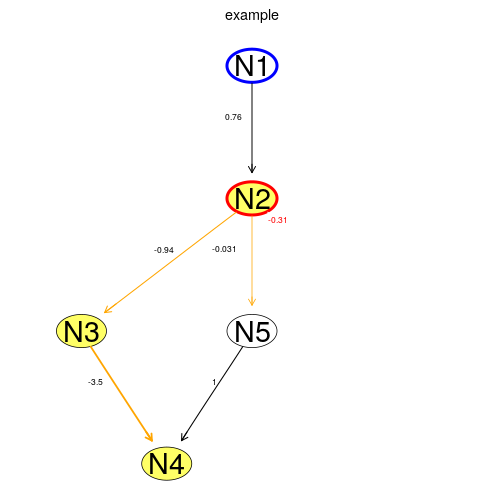

```r
plotModelGraph(model)
```

Be aware that the fitted values may represent paths, thus the values displayed on a link might stand for a combination of links (with the other dependent links given the strength 1). Use `printParameters()` to get the actual paths.

```r
printParameters(model)
```

```
## Parameters :
```

```
## [1] "N1->N2 : 0.76"
## [1] "N2->N3 : -0.94"
## [1] "N2->N5->N4 : -0.031"
## [1] "N3->N4 : -3.5"
## [1] "iN2 : -0.31"
```

Thus it can be noticed that the strength of N2->N5->N4 has in the above network been given to the link N2-> N5 with N5->N4 being set to 1.

### Data vs Model

We can evaluate how the simulation compares to the data using several ways. Using `plotModelAccuracy()` five heatmaps will be generated among which the experimental data and Simulated data being the Data and the fit, respectively. With `plotModelScores()` the individual goodness of fit for each analyte can be depicted as coefficient of Determination (R²). Using `plotModelSimulation()` analyte-wise bargraphs are plotted directly comparing data with simulation (not that by using `simulateModel()` one can also simulate novel not fitted perturbations or combinations thereof).

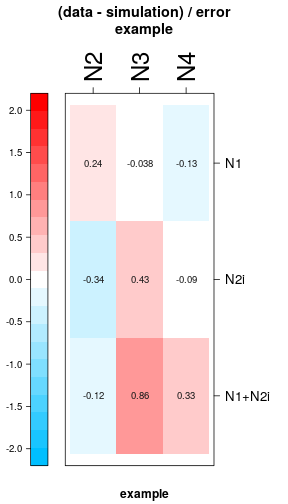

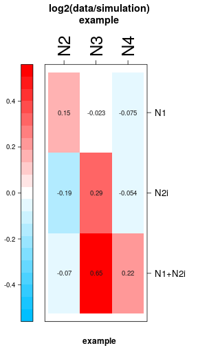

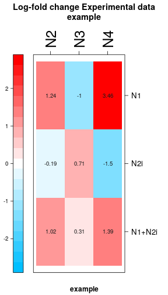

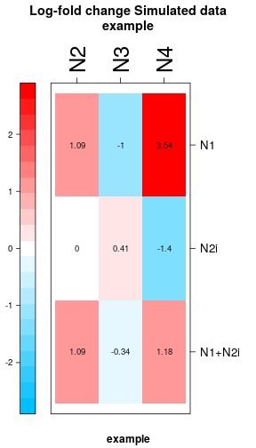

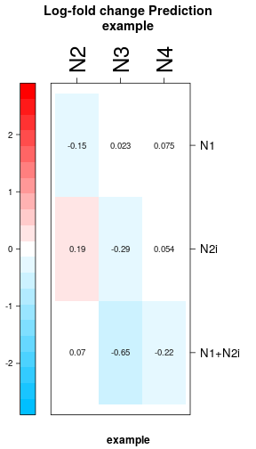

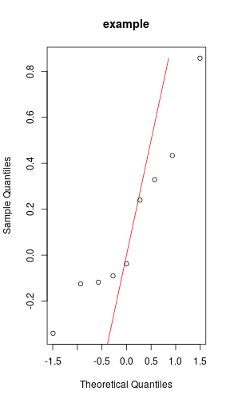

```r
plotModelAccuracy(model)
```

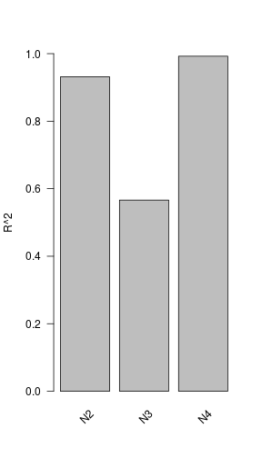

```r
plotModelScores(model)
```

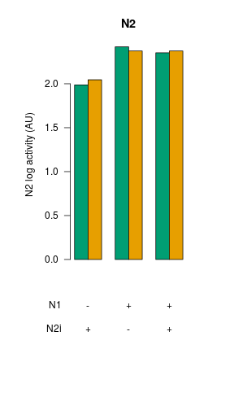

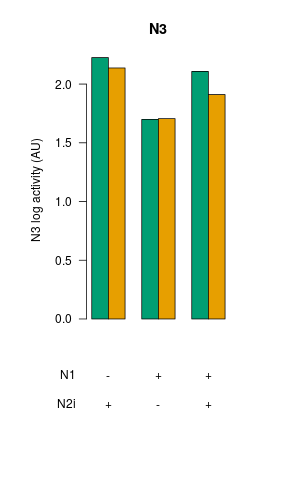

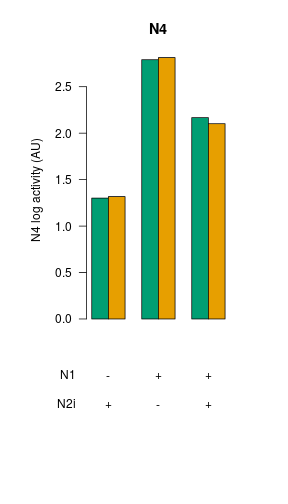

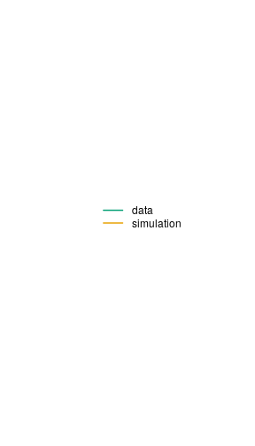

```r
simulation = plotModelSimulation(model, with_data= TRUE,log_axis = T)
```

```r
print(simulation)
```

```
## $conditions
##      N1 N2i
## [1,]  0   1
## [2,]  1   0
## [3,]  1   1
##
## $bestfit
##            N2        N3        N4
## [1,] 111.0000 137.09408  20.76361
## [2,] 236.2414  50.79591 650.79896
## [3,] 236.2414  81.43915 126.50908
##
## $variants
## list()
##
## $data
##       N2  N3  N4
## [1,]  97 168  20
## [2,] 263  50 618
## [3,] 225 128 147
##
## $error
##        N2   N3    N4
## [1,] 29.1 50.4   6.0
## [2,] 78.9 15.0 185.4
## [3,] 67.5 38.4  44.1
##
## $unstim_data
##      [,1] [,2] [,3]
## [1,]  111  103   56
## [2,]  111  103   56
## [3,]  111  103   56
```

### Profile likelihood

Profile likelihood aims at providing confidence intervals for the parameters. `niplotPL()` provides a convenient way to plot the likelihood and profiles of parameters.

```r
profiles = profileLikelihood(model, nb_points = 1000, nb_cores = 8)
```

```
## 5  paths to evaluate
```

```
## Residual = 1.24332874043369
```

```
## Residual score = 0.83004442155054
```

```
## N1->N2 = 0.755324012485042 ( 0.00532401248504135 - 1.21532401248504 )
```

```
## N2->N3 = -0.935907210741526 ( ni - -0.155907210741526 )
```

```
## N2->N5->N4 = -0.0313431115260781 (non identifiable)
```

```
## N3->N4 = -3.50329194987238 (non identifiable)
```

```
## iN2 = -0.30552008016136 ( -0.705520080161361 - 0 )
```

```
## Profiles sorted
```

```
## 3 non identifiable paths
```

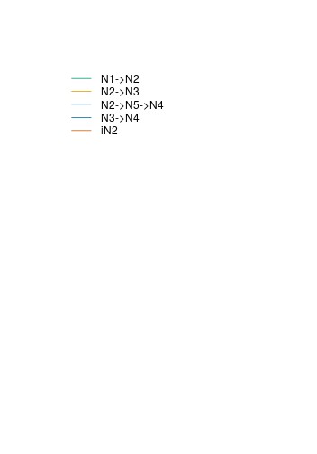

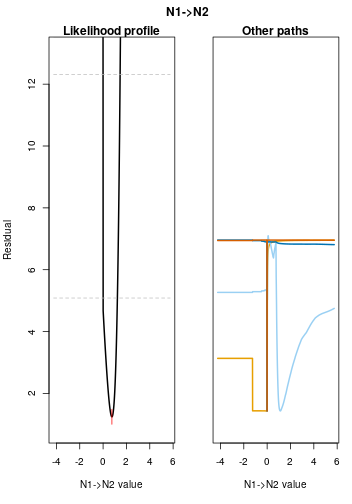

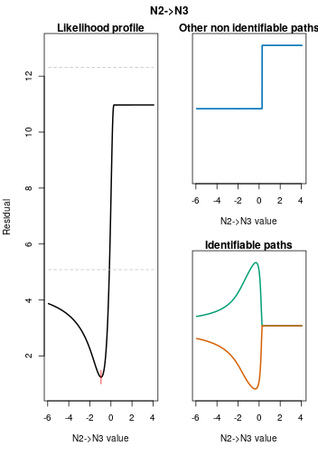

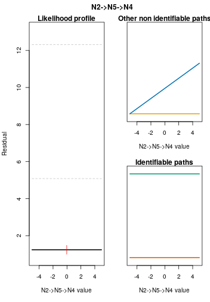

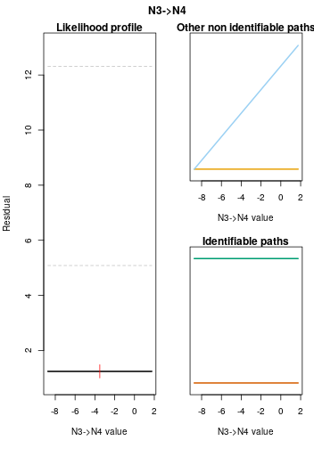

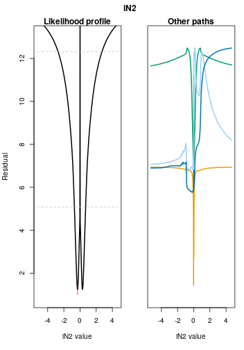

```r
model = addPLinfos(model, profiles)
niplotPL(profiles, file_plots = FALSE)
```

The two dashed lines denote family-wise and point-wise 95% confidence threshold, respectively.

Note the correlation between N3->N4 and N2->N4->N5 which indicates a structural non identifiability, i.e. the experimental design does not allow to differentiate between them. Note also the symmetry around 0 for the inhibitor iN2 due to the fact that the sign is ignored by the fitting routine and always assumed to be negative.

The resulting parameter confidence intervals can be visualised in the following way with dots (or if outside the plotting regions numbers) pointing to the actual parameter values and green bars denoting the 95% point-wise confidence interval.

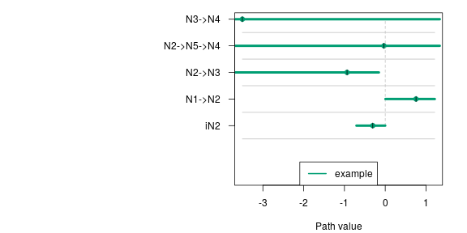

```r
plotModelParameters(model, lim = 4)
```

We can now also redo the simulation plot and include the confidence interval information as error bars .

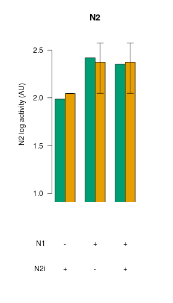

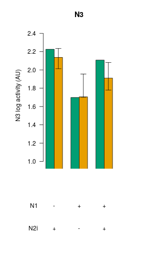

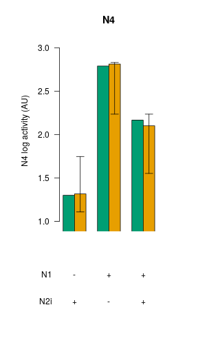

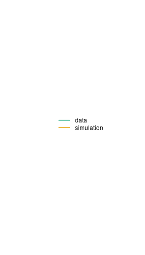

```r
simulation = plotModelSimulation(model, with_data= TRUE,log_axis = T)
```

### Network alteration

Next to the parameters (or more correctly identifiable combinations of response coefficients) also the structural sanity of the network can be assessed by searching for superfluous or missing connections.

First we try to reduce the network in order to test for links that do not significantly contribute to the overall fit

```r
red_model = selectMinimalModel(model)
```

```
## Performing model reduction...
```

```
## Remove link 4: N3->N4
```

```
## New residual =  1.24332874070827 , Delta residual =  2.7e-10 ,  p-value =  1.3e-05
```

```
## --- Other best links ---
```

```
##     Could remove N2->N5
```

```
##     New residual =  1.24332874283944 , Delta residual =  2.4e-09 ,  p-value =  3.9e-05
```

```
##     Could remove N5->N4
##     New residual =  1.24332874283944 , Delta residual =  2.4e-09 ,  p-value =  3.9e-05
```

```
## Reduction complete
```

After having reduced the model it is also of interest to search for missing links that would improve the overall fit. In contrast to the reduction this is done by returning a list which provides the improvement and strength of each link so that the extension can then be manually conducted by a manually altering the network structure (at best guided by available biological insights from previous experiments or literature) and rerunning the `createModel()` routine.

```r
ext_mat = suggestExtension(red_model)
```

```
##    adj_idx from to value residual df Res_delta df_delta pval adj_pval
## 2        4   N1 N4  1.23     0.26  5      0.98        1 0.32        1
## 3        5   N1 N5  1.23     0.26  5      0.98        1 0.32        1
## 1        3   N1 N3  0.69      0.3  5      0.95        1 0.33        1
## 11      22   N5 N2  0.26     1.13  5      0.11        1 0.74        1
## 8       17   N4 N2 0.087     1.13  5      0.11        1 0.74        1
## 5       12   N3 N2  -0.3     1.13  5      0.11        1 0.74        1
## 9       18   N4 N3 0.012     1.24  5   1.9e-10        1    1        1
## 10      20   N4 N5 -0.11     1.24  5   1.9e-10        1    1        1
## 7       15   N3 N5 -0.71     1.24  5   1.3e-10        1    1        1
## 6       14   N3 N4 -0.71     1.24  5     1e-10        1    1        1
## 4        9   N2 N4     0     1.24  5   2.2e-16        1    1        1
## 12      23   N5 N3     0     1.24  5   2.2e-16        1    1        1
```

In this toy example the data is already well represented with no significantly missing link (see multiple testing adjusted p-values column adj_pval).

Now that we have a satisfying model, it can be exported with `exportModel`. Note that the model *cannot* be saved as an RData object because of the underlying C++ code, it has to be saved with `exportModel`.

```r
exportModel(red_model, "best_model.mra")
```

The model can then be rebuilt with `importModel` (or with the more complex `rebuildModel` which allows to retrain the model with new data).

```r
red_model = importModel("best_model.mra")
```

## Modelset

A model set is the appropriate choice if several data sets are so similar that they can be jointly fitted with the same model and only some links are of need to be fitted individually between data sets. This would be the case for isogenic cell lines differing only by one mutation, or in different cell types of the same tissue (with identical genetic background).

We add a second data set were the difference is that N2 is more reactive to the stimulus than in the first data set (which is also propagated to the downstream nodes).

```r
midas_data2 = midas_data
midas_data2[,c(5:7)] = cbind(c(111, 803, 824, 97), c(103, 20, 341, 430), c(56, 1618, 190, 20)) # Measurements
print(midas_data)
```

```
##   ID:type TR:N1 TR:N2i DA:ALL DV:N2 DV:N3 DV:N4
## 1       c     0      0      0   111   103    56
## 2       t     1      0      0   263    50   618
## 3       t     1      1      0   225   128   147
## 4       t     0      1      0    97   168    20
```

```r
print(midas_data2)
```

```
##   ID:type TR:N1 TR:N2i DA:ALL DV:N2 DV:N3 DV:N4
## 1       c     0      0      0   111   103    56
## 2       t     1      0      0   803    20  1618
## 3       t     1      1      0   824   341   190
## 4       t     0      1      0    97   430    20
```

Now we can fit both data sets with one set of coefficients first using the `createModelSet()` function.

```r
mset = createModelSet(model_links = network,
                      basal_file = basal,
                      csv_files = list(midas_data, midas_data2),
                      model_name = c("example1","example2"),
                      inits = 1000)
```

```
## setting completed
```

```
## Initializing the model parameters... (1000 random samplings) with 1 cores
```

```
## Generating initial samples
```

```
## Sampling terminated.
```

```
## Fitting completed.
```

```
## Best residuals :
```

```
## 16.4925 16.4925 16.4925 16.4925 16.4925 16.4925 16.4925 16.4925 16.4925 16.4925 16.4925 16.4925 16.4925 16.4925 16.4925 16.4925 16.4925 16.4925 16.4925 16.4925
```

[output not shown]

In order to obtain the visualisation and extraction routines shown for the MRAmodel section the single model objects have to be extracted which can be treated like MRAmodels. The extraction is conducted as follows:

```r
modelgrp <- extractSubmodels(mset)
```

[output not shown]

```r
modelgrp$names
```

[output not shown]

```r
mramodel_ex1 = modelgrp$models[[1]]
```

[output not shown]

```r
mramodel_ex2 = modelgrp$models[[2]]
```

[output not shown]

The `Modelgroup` object resides between the Modelset and MRAModel structure and allows some basic visualisations such as the individual fitting scores.

```r
plotResiduals(modelgrp)
```

[output not shown]

[output not shown]

### Variable Links

So far we have only fitted one set of model coefficients that can on average explain two different data sets best. As we are interested in the link coefficients that have to be significantly different between those data sets (.i.e. instead of one coefficient here two data-set-specific coefficients have to be used) we apply a greedy-hill climbing likelihood ratio test-based routine in `addVariableParameter()`. The implementation iteratively makes those links variable that when allowed to vary between data sets most significantly improve the overall fit. In order to ensure robustness to this strategy the algorithm tests the variable links once more by the reverse operation (termed lumping).

```r
msetVar = addVariableParameters(mset)
```

[output not shown]

We can visualize the variable coefficients using `compareParameters()`.

```r
compareParameters(msetVar)
```

[output not shown]

[output not shown]

```r
modelgrpVar <- extractSubmodels(msetVar)
```

[output not shown]

```r
plotResiduals(modelgrpVar)
```

[output not shown]

[output not shown]

### Network alteration

The modelset object (including variable links) can now also be tested for network structure alterations by applying the very same functions used in the MRAmodel example above: `selectMinimalModel()` and `suggestExtension()`.